# PREDICTING THE SURVIVAL OF HEART FAILURE'S PATIENT IN PUNJAB, PAKISTAN

## Phase 1: Data Preparation and Visualisation

# Group Name: Group 49

# Name & ID:

> Le Gia Thinh Pham - 3749781

> Hoang Anh Kieu - 3877910

> Ngo Le Nhu Quynh - 3891803
- Introduction
  - Dataset Source
  - Dataset Details
  - Dataset Features
  - Target Feature
- Goals and Objectives
- Data Cleaning and Preprocessing
  - Displaying dataset's columns
  - Dropping irrelevant columns
  - Removing lower case and white spaces in columns' name
  - Check datatype of each columns
  - Converting datatype of the 'age' column
  - Checking if the column 'age' has negative values
  - Checking if the column 'age' has zero values
  - Checking the unique for each columns in the dataset
  - Checking if there are any missing values in the dataset
  - Random sampling
- Data Exploration and Visualisation
  - One-Variable Visualisation
  - Two-Variable Visualisation
  - Three-Variable Visualisation
- Literature Review
- Summary and Conclusion
- References

# Introduction

## Datasource

> The Heart Failure Clinical Records used in this report were sourced from UC Irvine (2020). The dataset includes the medical records of 299 patients who experienced heart failure from April to December 2015.

## Dataset Details

> The dataset is about the survival status of heart failure patients in Punjab, Pakistan, based on two main features: serum creatine and ejection fraction. Additional features recorded in this dataset are the patient's age, anaemia decrease, creatine phospokinase level, the likelihood of having diabetes, high blood pressure level, platelets, serum sodium level, patient's gender, patient's smoking habit, and follow-up period. All the mentioned features contributed to constructing a predictive modeling of heart failure patient's survival in Punjab, Pakistan as a categorical problem. The dataset includes 12 features and 299 observations.

**Dataset Retrieval**

- We read the dataset from our GitHub repository and loaded the modules we will use throughout this report.
- We display 10 randomly sampled rows from this dataset.

```python
import warnings
warnings.filterwarnings("ignore")

import numpy as np
import pandas as pd
import io
import requests

pd.set_option('display.max_columns', None)
```

```python
import matplotlib.pyplot as plt
import seaborn as sns
%matplotlib inline
%config InlineBackend.figure_format = 'retina'
plt.style.use("seaborn-v0_8")
```

```python
url_name = 'https://raw.githubusercontent.com/Timothy1509/MACHINE-LEARNING/refs/heads/main/heart_failure.csv'
url_content = requests.get(url_name, verify=False).content
df = pd.read_csv(io.StringIO(url_content.decode('utf-8')))
```

```python
df.shape
```

```
(299, 13)
```

```python
df.sample(n=10, random_state=8)
```

|  | age | anaemia | creatinine_phosphokinase | diabetes | ejection_fraction | high_blood_pressure | platelets | serum_creatinine | serum_sodium | sex | smoking | time | DEATH_EVENT |
| --- | --- | --- | --- | --- | --- | --- | --- | --- | --- | --- | --- | --- | --- |
| 297 | 45.0 | 0 | 2413 | 0 | 38 | 0 | 140000.00 | 1.40 | 140 | 1 | 1 | 280 | 0 |
| 107 | 45.0 | 1 | 1876 | 1 | 35 | 0 | 226000.00 | 0.90 | 138 | 1 | 0 | 88 | 0 |
| 154 | 65.0 | 1 | 335 | 0 | 35 | 1 | 235000.00 | 0.80 | 136 | 0 | 0 | 120 | 0 |
| 181 | 59.0 | 1 | 176 | 1 | 25 | 0 | 221000.00 | 1.00 | 136 | 1 | 1 | 150 | 1 |
| 55 | 95.0 | 1 | 371 | 0 | 30 | 0 | 461000.00 | 2.00 | 132 | 1 | 0 | 50 | 1 |
| 141 | 46.0 | 1 | 291 | 0 | 35 | 0 | 348000.00 | 0.90 | 140 | 0 | 0 | 109 | 0 |
| 139 | 50.0 | 0 | 1548 | 0 | 30 | 1 | 211000.00 | 0.80 | 138 | 1 | 0 | 108 | 0 |
| 243 | 73.0 | 1 | 1185 | 0 | 40 | 1 | 220000.00 | 0.90 | 141 | 0 | 0 | 213 | 0 |
| 56 | 70.0 | 1 | 75 | 0 | 35 | 0 | 223000.00 | 2.70 | 138 | 1 | 1 | 54 | 0 |
| 64 | 45.0 | 0 | 582 | 0 | 80 | 0 | 263358.03 | 1.18 | 137 | 0 | 0 | 63 | 0 |

## Dataset Features

> The table below displays the features of the dataset which was collected from the UCI Machine Learning Repository source.

```python
# !pip install tabulate

from tabulate import tabulate
table = [
    ["Name", "Data Type", "Units", "Description"],
    ["age", "Integer", "years", "Age of the patient"],
    ["anaemia", "Binary", "NA", "Decrease of red blood cells or hemoglobin"],
    ["creatinine_phosphokinase", "Integer", "NA", "Level of the CPK enzyme in the blood"],
    ["diabetes", "Binary", "NA", "If the patient has diabetes"],
    ["ejection_fraction", "Integer", "NA", "Percentage of blood leaving the heart at each contraction"],
    ["high_blood_pressure", "Binary", "NA", "If the patient has hypertension"],
    ["platelets", "Continuous", "NA", "Platelets in the blood"],
    ["serum_creatinine", "Continuous", "NA", "Level of serum creatinine in the blood"],
    ["serum_sodium", "Integer", "NA", "Level of serum sodium in the blood"],
    ["sex", "Binary", "Sex", "Gender of the patient (male/female)"],
    ["smoking", "Binary", "NA", "Whether the patient smokes"],
    ["time", "Integer", "NA", "Follow-up period (in days)"],
    ["death_event", "Binary", "NA", "Whether the patient died during follow-up"]
]

print(tabulate(table, headers='firstrow', tablefmt='fancy_grid'))
```

```
╒══════════════════════════╤═════════════╤═════════╤═══════════════════════════════════════════════════════════╕
│ Name                     │ Data Type   │ Units   │ Description                                               │
╞══════════════════════════╪═════════════╪═════════╪═══════════════════════════════════════════════════════════╡
│ age                      │ Integer     │ years   │ Age of the patient                                        │
├──────────────────────────┼─────────────┼─────────┼───────────────────────────────────────────────────────────┤
│ anaemia                  │ Binary      │ NA      │ Decrease of red blood cells or hemoglobin                 │
├──────────────────────────┼─────────────┼─────────┼───────────────────────────────────────────────────────────┤
│ creatinine_phosphokinase │ Integer     │ NA      │ Level of the CPK enzyme in the blood                      │
├──────────────────────────┼─────────────┼─────────┼───────────────────────────────────────────────────────────┤
│ diabetes                 │ Binary      │ NA      │ If the patient has diabetes                               │
├──────────────────────────┼─────────────┼─────────┼───────────────────────────────────────────────────────────┤
│ ejection_fraction        │ Integer     │ NA      │ Percentage of blood leaving the heart at each contraction │
├──────────────────────────┼─────────────┼─────────┼───────────────────────────────────────────────────────────┤
│ high_blood_pressure      │ Binary      │ NA      │ If the patient has hypertension                           │
├──────────────────────────┼─────────────┼─────────┼───────────────────────────────────────────────────────────┤
│ platelets                │ Continuous  │ NA      │ Platelets in the blood                                    │
├──────────────────────────┼─────────────┼─────────┼───────────────────────────────────────────────────────────┤
│ serum_creatinine         │ Continuous  │ NA      │ Level of serum creatinine in the blood                    │
├──────────────────────────┼─────────────┼─────────┼───────────────────────────────────────────────────────────┤
│ serum_sodium             │ Integer     │ NA      │ Level of serum sodium in the blood                        │
├──────────────────────────┼─────────────┼─────────┼───────────────────────────────────────────────────────────┤
│ sex                      │ Binary      │ Sex     │ Gender of the patient (male/female)                       │
├──────────────────────────┼─────────────┼─────────┼───────────────────────────────────────────────────────────┤
│ smoking                  │ Binary      │ NA      │ Whether the patient smokes                                │
├──────────────────────────┼─────────────┼─────────┼───────────────────────────────────────────────────────────┤
│ time                     │ Integer     │ NA      │ Follow-up period (in days)                                │
├──────────────────────────┼─────────────┼─────────┼───────────────────────────────────────────────────────────┤
│ death_event              │ Binary      │ NA      │ Whether the patient died during follow-up                 │
╘══════════════════════════╧═════════════╧═════════╧═══════════════════════════════════════════════════════════╛
```

## Target Feature

> The target feature for this dataset is 'DEATH_event' which is a binary categorical variable.

> In phase 2, the survival change of heart failure patients will be predicted based on the explanatory variables.

# Goals and Objectives

Cardiovascular diseases are a rising issue in Pakistan (Ashraf et al., 2023). Heart failure is one of the cardiovascular diseases. The disease refers to a situation when the heart can't pump enough blood to meet the body's needs.

This insufficiency might be caused by the heart's lower capacity to pump blood efficiently or by its incapability to fill with adequate blood. Severe impacts of heart failure include pulmonary hypertension, heart valve problems, liver and kidney disease, and even cardiac arrest.

The symptoms could lead to a life-threatening nature if not detected and cured immediately. Thus, a model that can accurately predict the survival chance of heart failure patients could help with early prevention and reduce the death rate in the country.

The main objectives of this project include the following:

> (1) Perform data preprocessing and data exploration and visualization of the dataset to better complete the following objectives.

> (2) Predict the survival of heart failure patient in Punjab, Pakistan based on the provided features.

> (3) Determine the best predictors among the provided features to forecast the survival of heart failure patients.

As the dataset is not a time series obbject and each row represents a unique patient, it is compulsory to assume that the observations are independent and uncorrelated.

Although the dataset includes a follow-up-period variable, it displays the duration of observation for each individual patient rather than repeated measurements over time. Hence, there is no temporal dependcy accross rows. For that reason, the assumption supports the use of standard machine learning models that assume independent and identically distributed observations. Treating each record as an independent case allows for appropriate model training and evaluation without concern for autocorrelation or sequence-based bias.

# Data Cleaning and Preprocessing

Data Cleaning Steps

This section outlines the preprocessing and data-cleaning procedures used for this research.

- Drop irrelevant features in our dataset
- Check and rename/modify some column names
- Check for missing values
- Remove all the rows with missing values
- Random sampling of the dataset

Let's first display all the columns in our dataset.

## Displaying dataset's colums

```python
df.columns
```

```
Index(['age', 'anaemia', 'creatinine_phosphokinase', 'diabetes',
       'ejection_fraction', 'high_blood_pressure', 'platelets',
       'serum_creatinine', 'serum_sodium', 'sex', 'smoking', 'time',
       'DEATH_EVENT'],
      dtype='object')
```

## Dropping irrelevant columns

```python
df = df.set_index('smoking')
```

> The 'smoking' column is irrelevant to the prediction of heart failure patients' survival status. Hence, the feature is set as an index.

> Smoking is not a strongly relevant predictor of heart failure survival as it does not significantly impact short-term mortality once heart failure has already occurred.

## Removing lower case and white spaces in columns' name

```python
df.columns = df.columns.str.lower().str.strip()
```

> Then, we standardize the column names by transforming them all lowercase and trimming any extra spaces at the beginning or end. This will help prevent any problems while modeling.

## Check datatype of each columns

```python
print(f"Shape of the dataset = {df.shape} \n")
print(f"Data types are below where 'object' indicates a string type: ")
print(df.dtypes)
```

```
Shape of the dataset = (299, 12)

Data types are below where 'object' indicates a string type:
age                         float64
anaemia                       int64
creatinine_phosphokinase      int64
diabetes                      int64
ejection_fraction             int64
high_blood_pressure           int64
platelets                   float64
serum_creatinine            float64
serum_sodium                  int64
sex                           int64
time                          int64
death_event                   int64
dtype: object
```

> After checking the datatype of each column, we noticed that the data type of the 'age' column is float64 which contains decimal values. Hence, it is irrelevant for the age record to have decimal values. Thus, we convert the datatype of the 'age' column to an integer.

## Converting datatype of the 'age' column

```python
df['age'] = df['age'].astype('int64')
```

## Checking if the column 'age' has negative values

```python
(df['age'] < 0).any()
```

```
np.False_
```

> According to the output, the 'age" column does not contain negative values.

## Checking if the column 'age' has zero values

```python
(df['age'] == 0).any()
```

```
np.False_
```

> According to the output, the 'age' column does not contain any zero values.

## Checking the unique for each columns in the dataset

```python
from IPython.display import display, HTML
display(HTML('<b>Table 1: Summary of numerical features</b>'))
df.describe(include=['int64','float64']).T
```

**Table 1: Summary of numerical features**

|  | count | mean | std | min | 25% | 50% | 75% | max |
| --- | --- | --- | --- | --- | --- | --- | --- | --- |
| age | 299.0 | 60.829431 | 11.894997 | 40.0 | 51.0 | 60.0 | 70.0 | 95.0 |
| anaemia | 299.0 | 0.431438 | 0.496107 | 0.0 | 0.0 | 0.0 | 1.0 | 1.0 |
| creatinine_phosphokinase | 299.0 | 581.839465 | 970.287881 | 23.0 | 116.5 | 250.0 | 582.0 | 7861.0 |
| diabetes | 299.0 | 0.418060 | 0.494067 | 0.0 | 0.0 | 0.0 | 1.0 | 1.0 |
| ejection_fraction | 299.0 | 38.083612 | 11.834841 | 14.0 | 30.0 | 38.0 | 45.0 | 80.0 |
| high_blood_pressure | 299.0 | 0.351171 | 0.478136 | 0.0 | 0.0 | 0.0 | 1.0 | 1.0 |
| platelets | 299.0 | 263358.029264 | 97804.236869 | 25100.0 | 212500.0 | 262000.0 | 303500.0 | 850000.0 |
| serum_creatinine | 299.0 | 1.393880 | 1.034510 | 0.5 | 0.9 | 1.1 | 1.4 | 9.4 |
| serum_sodium | 299.0 | 136.625418 | 4.412477 | 113.0 | 134.0 | 137.0 | 140.0 | 148.0 |
| sex | 299.0 | 0.648829 | 0.478136 | 0.0 | 0.0 | 1.0 | 1.0 | 1.0 |
| time | 299.0 | 130.260870 | 77.614208 | 4.0 | 73.0 | 115.0 | 203.0 | 285.0 |
| death_event | 299.0 | 0.321070 | 0.467670 | 0.0 | 0.0 | 0.0 | 1.0 | 1.0 |

## Checking if there are any missing values in the dataset

```python
print(f"\nNumber of missing values for each column/ feature:")
print(df.isnull().sum())
```

```
Number of missing values for each column/ feature:
age                         0
anaemia                     0
creatinine_phosphokinase    0
diabetes                    0
ejection_fraction           0
high_blood_pressure         0
platelets                   0
serum_creatinine            0
serum_sodium                0
sex                         0
time                        0
death_event                 0
dtype: int64
```

> Missing values are checked by displaying the number of missing values in every column. It represents no missing values, so we do not need to drop any observations.

## Random sampling

> Since there are 299 rows in the data, it satisfies the minimal criterion of 200 rows, hence random sampling is not required.

# Data Exploration & Visualisation

## One-Variable Visualisation

### Histogram of Age

> According to figure 1, the distribution of patients' age is skewed slightly to the right, with the majority of patients are between the age of 55 and 70 years old, and fewer older patients extending into the 80s and 90s.

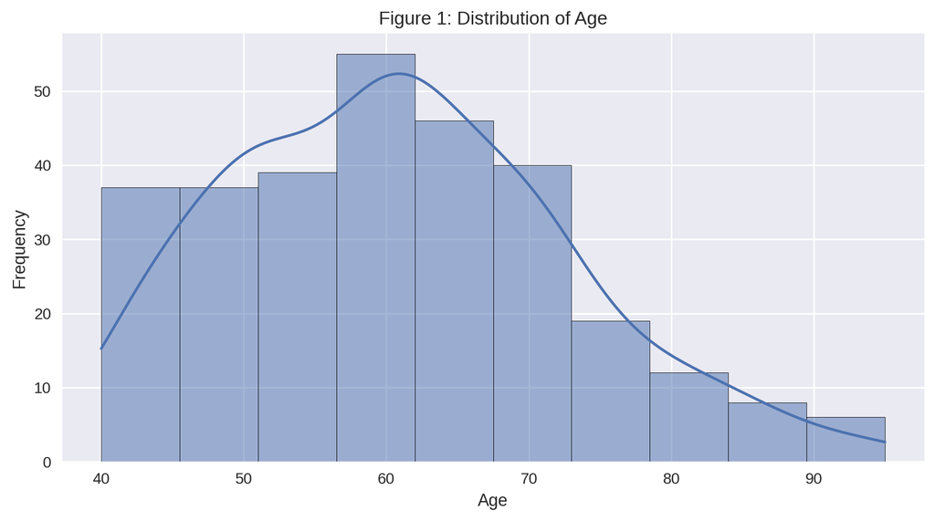

```python
plt.figure(figsize=(10, 5))
sns.histplot(df['age'], kde=True)
plt.title('Figure 1: Distribution of Age')
plt.xlabel('Age')
plt.ylabel('Frequency')
plt.show()
```

### Count Plot of Sex

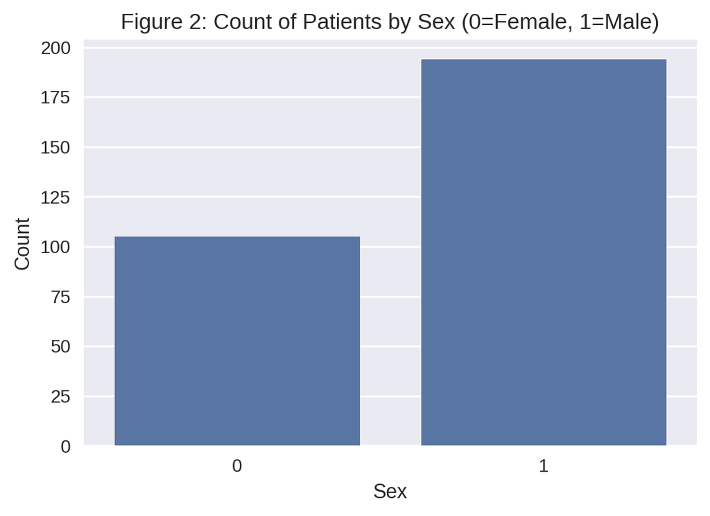

```python
plt.figure(figsize=(6, 4))
sns.countplot(x='sex', data=df)
plt.title('Figure 2: Count of Patients by Sex (0=Female, 1=Male)')
plt.xlabel('Sex')
plt.ylabel('Count')
plt.show()
```

### Boxplot of Serum Creatinine

> According to figure 3, the boxplot shows a right-skewed distribution with notable outliers. Higher serum creatinine values can indicate kidney dysfunction, which is a relevant risk factor for heart failure.

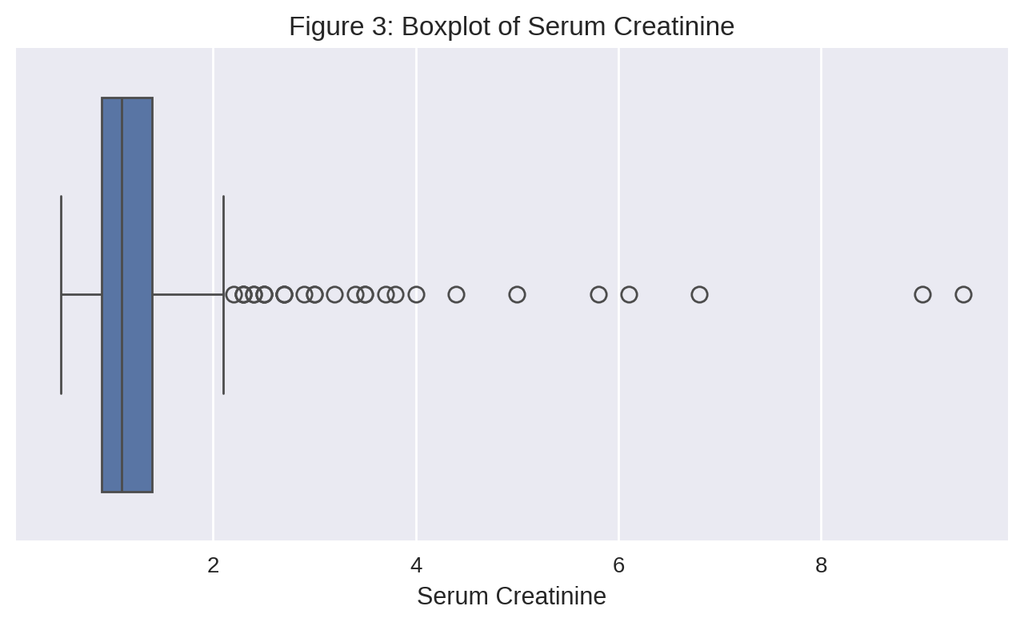

```python
plt.figure(figsize=(8, 4))
sns.boxplot(x=df['serum_creatinine'])
plt.title('Figure 3: Boxplot of Serum Creatinine')
plt.xlabel('Serum Creatinine')
plt.show()
```

### Histogram of Platelets

> According to figure 4, this histogram shows the platelet count distribution. It is relatively symmetric, though there are a few extremely high values, possibly indicating underlying medical conditions.

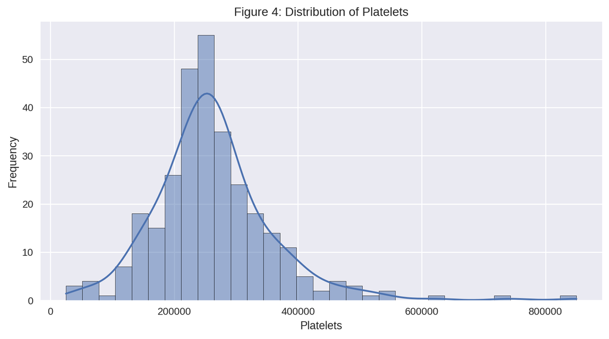

```python
plt.figure(figsize=(10, 5))
sns.histplot(df['platelets'], kde=True)
plt.title('Figure 4: Distribution of Platelets')
plt.xlabel('Platelets')
plt.ylabel('Frequency')
plt.show()
```

## Two-Variable Visualisation

### Age and Death Event

> According to Figure 5, this boxplot compares age across the death outcome groups. Patients who died during follow-up generally had higher ages, suggesting that age may play a role in survival.

```python
print(df.columns)
```

```
Index(['age', 'anaemia', 'creatinine_phosphokinase', 'diabetes',
       'ejection_fraction', 'high_blood_pressure', 'platelets',
       'serum_creatinine', 'serum_sodium', 'sex', 'time', 'death_event'],
      dtype='object')
```

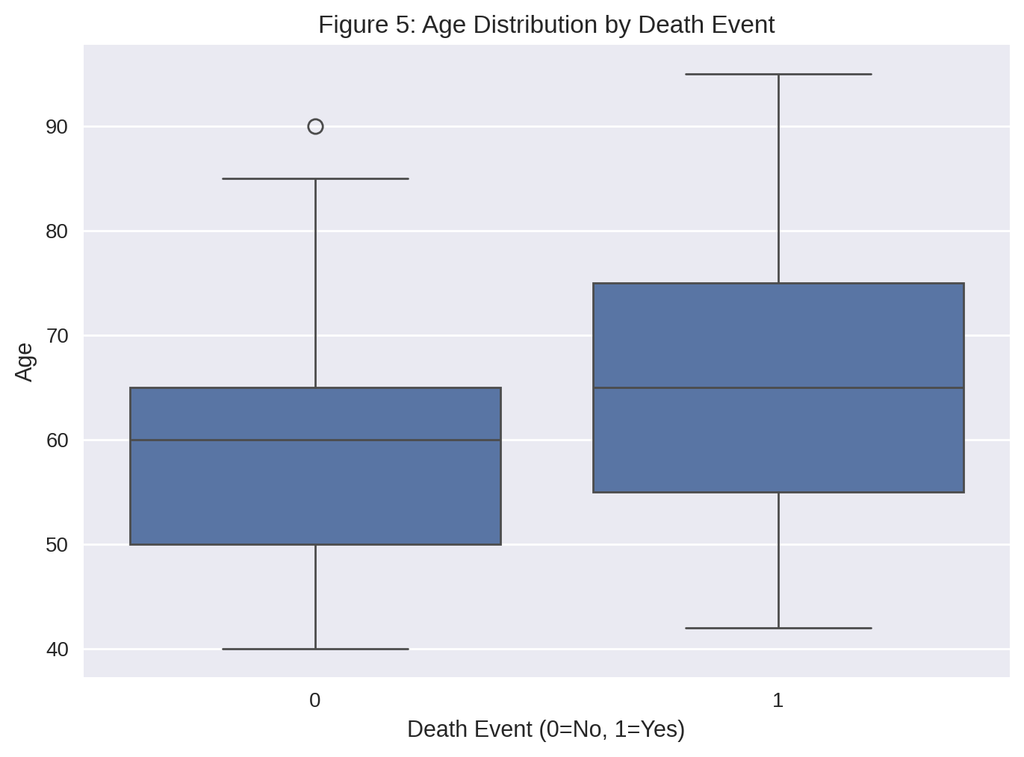

```python
plt.figure()
sns.boxplot(x='death_event', y='age', data=df)
plt.title('Figure 5: Age Distribution by Death Event')
plt.xlabel('Death Event (0=No, 1=Yes)')
plt.ylabel('Age')
plt.show()
```

### Serum Creatinine vs Death Event

> According to figure 6, higher levels of serum creatinine are more prevalent among patients who experienced death events. This further supports its importance as a risk indicator.

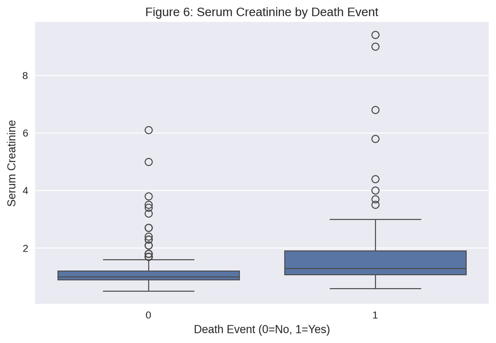

```python
plt.figure(figsize=(8, 5))
sns.boxplot(x='death_event', y='serum_creatinine', data=df)
plt.title('Figure 6: Serum Creatinine by Death Event')
plt.xlabel('Death Event (0=No, 1=Yes)')
plt.ylabel('Serum Creatinine')
plt.show()
```

### Creatinine Phosphokinase vs Death Event

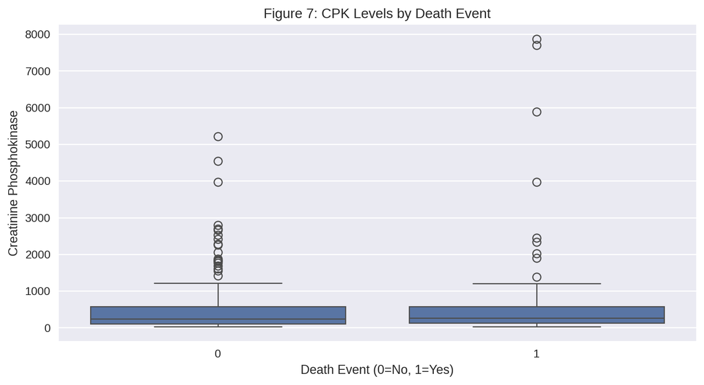

```python
plt.figure(figsize=(10, 5))
sns.boxplot(x='death_event', y='creatinine_phosphokinase', data=df)
plt.title('Figure 7: CPK Levels by Death Event')
plt.xlabel('Death Event (0=No, 1=Yes)')
plt.ylabel('Creatinine Phosphokinase')
plt.show()
```

### Ejection Fraction vs Death Event

> According to figure 8, patients with lower ejection fraction percentages were more likely to experience a death event, which aligns with clinical expectations, as low ejection fraction reflects poor heart pumping efficiency.

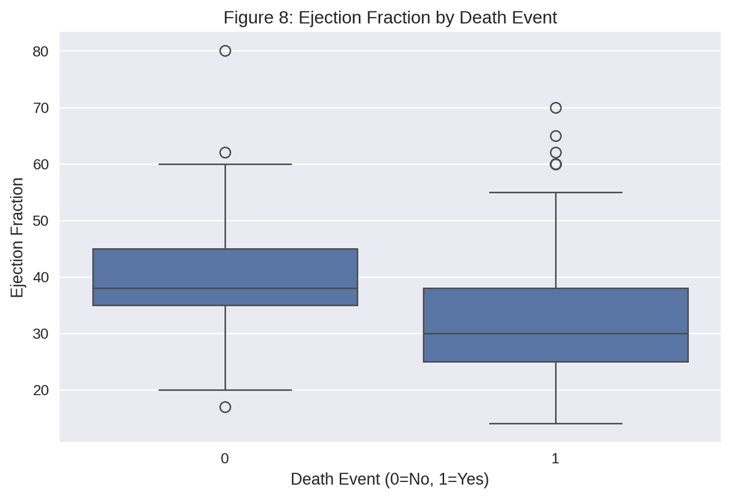

```python
plt.figure(figsize=(8, 5))
sns.boxplot(x='death_event', y='ejection_fraction', data=df)
plt.title('Figure 8: Ejection Fraction by Death Event')
plt.xlabel('Death Event (0=No, 1=Yes)')
plt.ylabel('Ejection Fraction')
plt.show()
```

## Three-Variable Visualisation

### Age vs Serum Creatinine colored by Death Event

> According to figure 9, this scatter plot indicates that higher serum creatinine levels are especially dangerous in older patients, as more death events are clustered in this region.

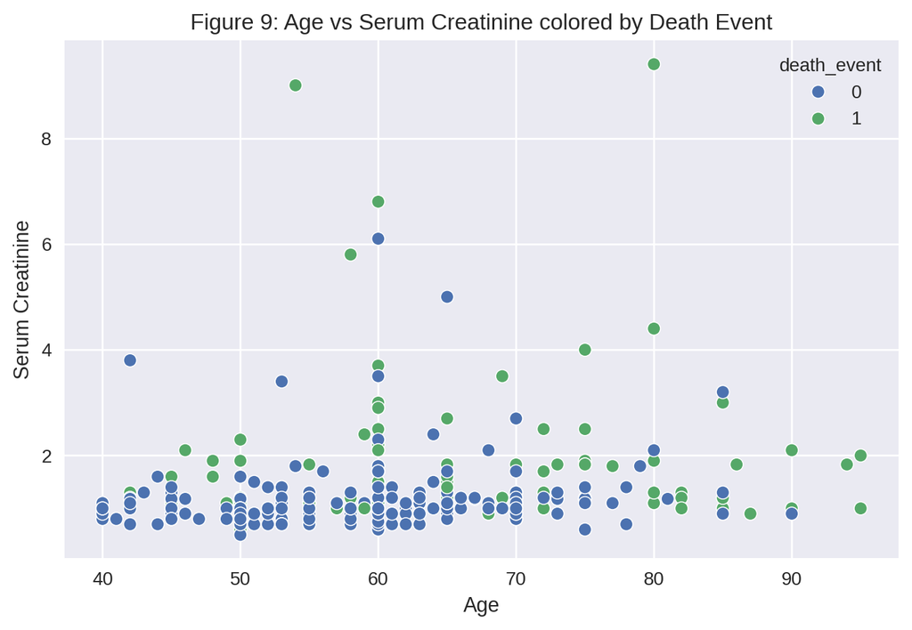

```python
plt.figure(figsize=(8, 5))
sns.scatterplot(x='age', y='serum_creatinine', hue='death_event', data=df)
plt.title('Figure 9: Age vs Serum Creatinine colored by Death Event')
plt.xlabel('Age')
plt.ylabel('Serum Creatinine')
plt.show()
```

### Platelets vs Ejection Fraction colored by Death Event

> According to figure 10, this plot suggests that low ejection fraction combined with irregular platelet counts may be more common in patients who did not survive.

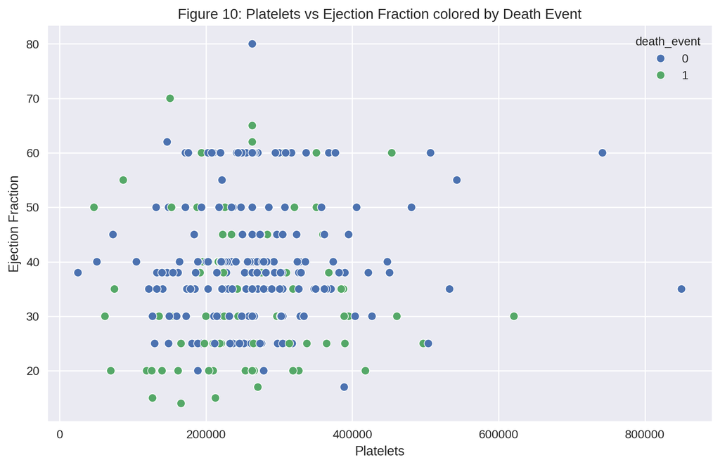

```python
plt.figure(figsize=(10, 6))
sns.scatterplot(x='platelets', y='ejection_fraction', hue='death_event', data=df)
plt.title('Figure 10: Platelets vs Ejection Fraction colored by Death Event')
plt.xlabel('Platelets')
plt.ylabel('Ejection Fraction')
plt.show()
```

### Serum Sodium vs Age colored by Sex

> According to figure 11, the distribution of serum sodium appears fairly consistent across ages for both males and females. Some slight deviations are visible in older age brackets.

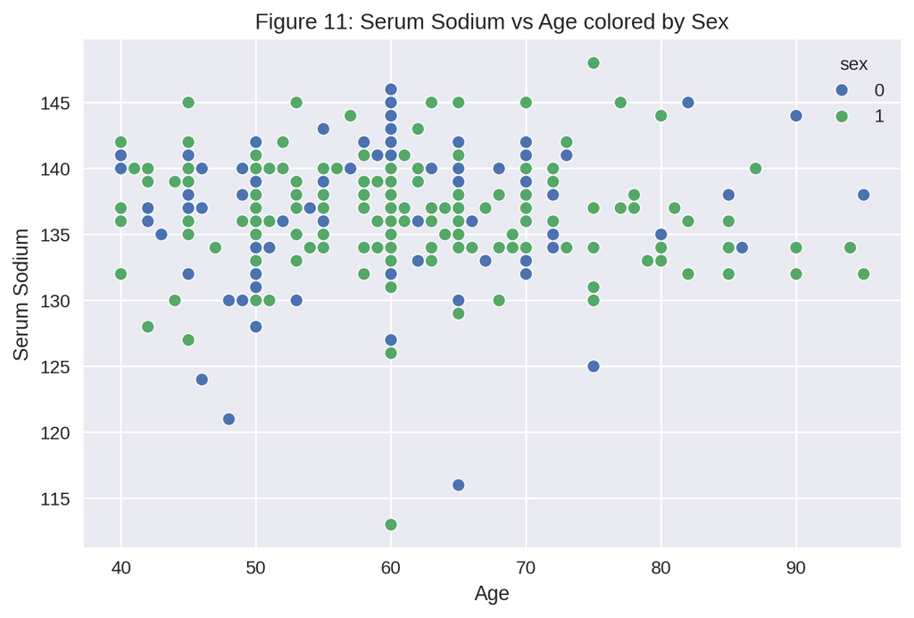

```python
plt.figure(figsize=(8, 5))
sns.scatterplot(x='age', y='serum_sodium', hue='sex', data=df)
plt.title('Figure 11: Serum Sodium vs Age colored by Sex')
plt.xlabel('Age')
plt.ylabel('Serum Sodium')
plt.show()
```

### Time vs Serum Creatinine colored by Death Event

> According to figure 12, patients who survived generally had longer follow-up times and lower serum creatinine levels. Those with higher levels often died earlier in the observation period.

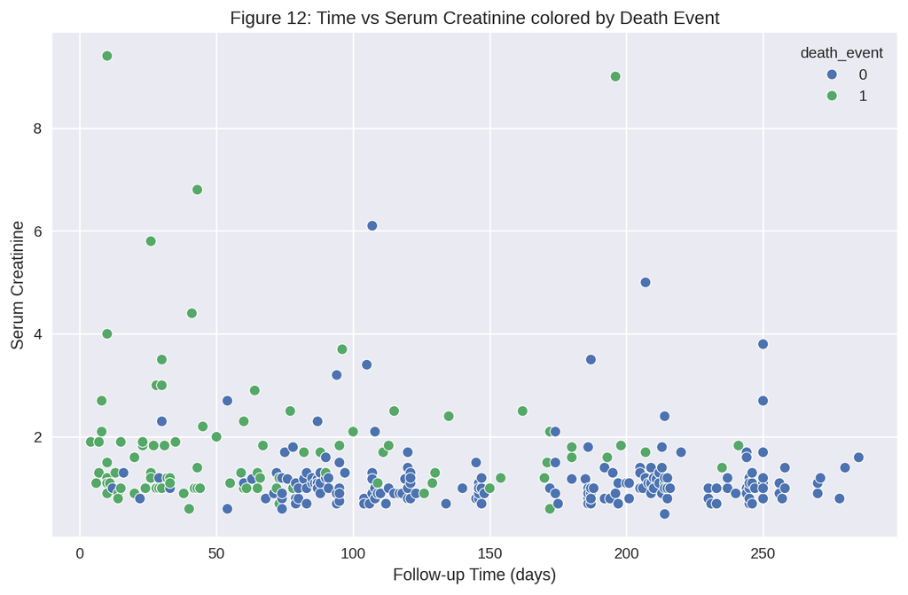

```python
plt.figure(figsize=(10, 6))
sns.scatterplot(x='time', y='serum_creatinine', hue='death_event', data=df)
plt.title('Figure 12: Time vs Serum Creatinine colored by Death Event')
plt.xlabel('Follow-up Time (days)')
plt.ylabel('Serum Creatinine')
plt.show()
```

# Literature Review

> Heart failure also known as congestive heart failure, is a complex clinical condition that arises when the heart cannot pump sufficient blood to satisfy the body’s metabolic demands. This insufficiency might be caused by the heart's lower capacity to pump blood efficiently or by its incapacity to fill with adequate blood. Severe consequences of heart failure might include pulmonary hypertension, heart valve problems, liver and kidney disease, and even cardiac arrest.

> In heart failure, accurately predicting patient survival is essential for enhancing treatment plans and patient outcomes. In recent studies, it suggests that machine learning is a tool for evaluate and forecast the patient outcomes. With a focus on studies that use serum creatinine and ejection fraction as key inputs, this literature review examines the state of the art in ML-based prediction models for heart failure survival.

> Since ML algorithms can capture complex, non-linear relationships within data, they offer advantages over traditional statistical methods. For example, Chicco and Jurman (2020) showed that ML classifiers could predict patient survival using only serum creatinine and ejection fraction, achieving higher accuracy than models incorporating a wider range of features. ML algorithms have been used to predict outcomes in HF patients. Similarly, Al’Aref et al. (2018) proposed a decision tree, Artificial neural networks (ANN), Support vector machine (SVM), and k-nearest neighbors (KNN) models trained on their dataset which outperformed traditional statistical approaches. The study demonstrated how machine learning (ML) may enhance risk assessment and individualized treatment regimens.

> Ejection fraction and serum creatinine are important indicators for determining the severity and prognosis of heart failure. Ejection fraction measures the percentage of blood the left ventricle pumps out with each contraction, indicating cardiac efficiency, while serum creatinine reflects renal function, which is frequently impaired in HF patients. Zamora et al. (2007) highlighted the fact that these two biomarkers were enough for predicting patient survival on their own, indicating that essential feature-focused, streamlined models may be both useful and understandable. In order to assess how well different ML models predict HF outcomes, comparative assessments have been carried out. For instance, Yang et al. presented a two-layer binary SVM classification method that was trained on clinical data from 289 patients. These patients were first classified as either having heart failure or being sent to secondary triage if the diagnosis was unclear. Following that, members of the latter group were classified as either healthy or at risk for heart failure. With 74.4% overall classification accuracy, our model identified healthy, heart failure-prone, and heart failure patients with accuracies of 78.79%, 87.5%, and 65.85%, respectively. Another study by Aljaaf et al. suggested a decision-tree model trained on the Cleveland Clinic Heart Disease Data Set, consisting of 297 patients each identified by 13 clinical variables, which stratified individuals into one of five risk groups for the development of heart failure. 10-fold cross-validation was used to assess the model's performance on the training set. The model's classification accuracy was 86.5%, and its mean AUC was 0.91. Besides, Wu et al. showed that logistic regression and boosting may be used to predict the onset of heart failure more than six months before a formal clinical diagnosis was made using a registry derived from electronic health records that included 536 patients. Their reported AUC on 10-fold cross-validation was 0.77. Using random forests, bagged regression trees, and boosted regression trees, Austin et al. attempted to build a binary tree-based classifier in 2013 that could accurately distinguish between heart failure with retained ejection fraction and heart failure with lower ejection fraction. The classifier was trained on 3697 and 4515 heart failure patients, respectively. Demographic and clinical characteristics, such as presenting vital signs, physical exam results, symptoms, laboratory tests, and previous medical history, were used to describe each participant in the research. Overall, logistic regression outperformed all of the previously described classification methods, whereas tree-based ensemble classifiers outperformed regression trees and traditional classification.

> ML may frequently produce correct predictions, but when decisions frequently have life-altering consequences, it can be troublesome when the human asking the question is unable to completely understand the intricacy of these algorithms' inner workings—the so-called "black box” (Castelvecchi 2016).

> Selection bias, which encompasses sample and observer selection bias, is one such hazard. Although selection bias is frequently lessened in carefully planned clinical trials, it is challenging to detect and address in ML datasets. There have been several documented instances of machine learning (ML) going wrong, which is a less benign manifestation of selection bias. This is not because the fundamental algorithm was defective; rather, it was because it made inferences from seriously erroneous data. To be transparent, when consumers learned about overt racial and socioeconomic inequality, several internet applications sparked public outrage. As it happens, these automatic behaviors were inadvertently added to the platforms by using unfiltered data coming from the Internet, where these kinds of opinions are frequently expressed anonymously (Garcia, 2016; Hajian, Bonchi, & Castillo, 2016; Kirkpatrick, 2016)

> In the future, Explainable artificial intelligence (XAI), a recent development in machine learning, will improve the models' suitability for use in therapeutic settings. To enhance HF survival prediction models, Moreno-Sanchez (2023) suggested an XAI-driven method, which is a model using an Extra Trees classifier over specific characteristics that achieved a balanced accuracy of 85.1%. Machine learning-based systems for predicting heart disease can offer patients and healthcare professionals clear, understandable, and actionable insights by utilizing these explainable AI techniques. This will help patients make better decisions and increase confidence in AI-driven healthcare applications.

# Summary and Conclusions

> To identify the elements that lead to patient death, we performed an end-to-end exploratory analysis of a heart failure dataset in the first phase of our study. The dataset focuses on the heart failure survival status of patients in Punjab, Pakistan, with records collected over an eight-month period from April to December 2015. Five main activities made up the analysis, which logically progressed from comprehending the dataset to visually exploring it for significant insights.

> We started by outlining our dataset's source in straightforward terms and providing comprehensive details about its composition and contents. To provide readers with a concrete knowledge of the data, this included the quantity of observations and characteristics. Additionally, we produced a comprehensive table that listed all of the features that were chosen for our project, along with their categories, units, and analytical responsibilities. **DEATH_EVENT**, our target feature, was found to be a binary categorical variable that indicates if the patients survived during the follow-up period.

> After that, we described the aims and purposes of our modeling assignment: (1) Predicting a patient's chance of dying based on clinical and demographic characteristics is the main goal.  
> (2) Utilizing data-driven insights to promote early intervention and enhance patient outcomes is what drives us.

> We examined the dataset for probable outliers, inaccurate entries, and missing values as part of the data cleaning and preparation operation. During this process, we identified that the 'age' column had an incorrect data type, which we corrected by converting it to an appropriate numerical format. Additionally, the 'smoking' column was set to index as it was deemed irrelevant to the goals of our prediction task. After completing these steps, the dataset was confirmed to be clean and fully prepared for modeling.

> We are now well-prepared for the project's next step, which involves constructing and evaluating models. We now understand the linkages between characteristics and outcomes, have a firm grasp of our data, and have well-defined modeling objectives.

# References

> Al’Aref SJ, Anchouche K, Singh G, Slomka PJ, Kolli KK, Kumar A, Pandey M, Maliakal G, van Rosendael AR, Beecy AN, Berman DS, Leipsic J, Nieman K, Andreini D, Pontone G, Schoepf UJ, Shaw LJ, Chang H-J, Narula J, Bax JJ, Guan Y, Min JK (2018). Clinical applications of machine learning in cardiovascular disease and its relevance to cardiac imaging. Eur Heart J. 2018; 40(24):1975–86.

> Aljaaf AJ, Al-Jumeily D, Hussain AJ, Dawson T, Fergus P, Al-Jumaily M (2015). Predicting the likelihood of heart failure with a multi level risk assessment using decision tree. *In 3rd 2015 International Conference on Technological Advances in Electrical, Electronics and Computer Engineering*.

> Ashraf, H., Farooq, S., Mehmood, T., Zafar, A., Manzoor, M., & Saeed, M. (2023). A machine learning approach for heart failure prediction in the Pakistani population: A retrospective study. *Pakistan Journal of Medical Sciences*, 39(6), 1683–1689. https://doi.org/10.12669/pjms.39.6.8335

> Austin, P. C., Tu, J. V., Ho, J. E., Levy, D., & Lee, D. S. (2013). Using methods from the data-mining and machine-learning literature for disease classification and prediction: a case study examining classification of heart failure subtypes. *Journal of clinical epidemiology*, 66(4), 398-407.

> Castelvecchi, D. (2016). Can we open the black box of AI?. *Nature News*, 538(7623), 20.

> Chicco, D., & Jurman, G. (2020). Machine learning can predict survival of patients with heart failure from serum creatinine and ejection fraction alone. *BMC medical informatics and decision making*, 20, 1-16.

> Garcia M (2016). Racist in the machine the disturbing implications of algorithmic bias. *World Policy Journal* ;33:111–117.

> Hajian, S., Bonchi, F., & Castillo, C. (2016, August). Algorithmic bias: From discrimination discovery to fairness-aware data mining. *In Proceedings of the 22nd ACM SIGKDD international conference on knowledge discovery and data mining* (pp. 2125-2126).

> Kirkpatrick, K. (2016). Battling algorithmic bias: how do we ensure algorithms treat us fairly?. *Communications of the ACM*, 59(10), 16-17.

> Moreno-Sánchez, P. A. (2023). Improvement of a prediction model for heart failure survival through explainable artificial intelligence. Frontiers in cardiovascular medicine, 10, 1219586.

> Wu, J., Roy, J., & Stewart, W. F. (2010). Prediction modeling using EHR data: challenges, strategies, and a comparison of machine learning approaches. *Medical care*, 48(6), S106-S113.

> Yang, G., Ren, Y., Pan, Q., Ning, G., Gong, S., Cai, G., ... & Yan, J. (2010, October). A heart failure diagnosis model based on support vector machine. In *2010 3rd international conference on biomedical engineering and informatics* (Vol. 3, pp. 1105-1108). IEEE.

> Zamora, E., Lupón, J., Urrutia, A., González, B., Mas, D., Díez, C., ... & Valle, V. (2007). Prognostic significance of creatinine clearance in patients with heart failure and normal serum creatinine. *Rev. Esp. Cardiol*, 60(12), 1315-1318.